# rebuttal

```python
import sys
sys.path.append('../')

import os
import json
import numpy as np
from natsort import natsorted
import matplotlib.pyplot as plt
import pandas as pd
from tqdm import tqdm
from scipy.stats import gmean
from phoenix.synthesis import grouping, ordering
from phoenix.models import HamiltonianModel, Clifford2Q, BSF
from phoenix import Circuit
from phoenix import models
from phoenix.utils import passes
```

### IR (Pauli string) grouping

For the expression of IR grouping method, Pauli strings are grouped based on the set of qubit indices where the corresponding Pauli operators are non-identity ('I'). Each group consists of Pauli strings that act non-trivially (i.e., with X, Y, or Z) on the same set of qubits

**E.g., list of random Pauli strings**

```python
def random_pauli(n: int) -> str:
    return ''.join(np.random.choice(['X', 'Y', 'Z', 'I'], n, replace=True))
```

```python
np.random.seed(123)
paulis = [random_pauli(4) for _ in range(15)]
paulis = [pauli for pauli in paulis if pauli.count('I') < 2]
print(paulis)
```

```
['ZYZZ', 'XZZY', 'ZYXY', 'ZIYX', 'ZXIY', 'IZYX', 'XXXY', 'XYXI', 'YIXX', 'XZYY', 'ZZIZ', 'YXXI']
```

```python
grouping.group_paulis(paulis)
```

```
{(0, 1, 2, 3): ['ZYZZ', 'XZZY', 'ZYXY', 'XXXY', 'XZYY'],
 (0, 1, 2): ['XYXI', 'YXXI'],
 (0, 1, 3): ['ZXIY', 'ZZIZ'],
 (0, 2, 3): ['ZIYX', 'YIXX'],
 (1, 2, 3): ['IZYX']}
```

**E.g., 1D periodic Heisenberg model (five spins)**

$H = H_x + H_y + H_z + H_0 = H_I + H_0 = \sum_{<i,j>}(J_x X_i X_j + J_y Y_i Y_j + J_z Z_i Z_j) + \sum_i h_i Z_i$

```python
ham = models.Heisenberg1D(Jx=0.1, Jy=0.2, Jz=0.3, h=np.repeat(1, 5))
print(ham.paulis)
```

```
['XXIII', 'IXXII', 'IIXXI', 'IIIXX', 'XIIIX', 'YYIII', 'IYYII', 'IIYYI', 'IIIYY', 'YIIIY', 'ZZIII', 'IZZII', 'IIZZI', 'IIIZZ', 'ZIIIZ', 'ZIIII', 'IZIII', 'IIZII', 'IIIZI', 'IIIIZ']
```

```python
grouping.group_paulis(ham.paulis)
```

```
{(0, 1): ['XXIII', 'YYIII', 'ZZIII'],
 (2, 3): ['IIXXI', 'IIYYI', 'IIZZI'],
 (0, 4): ['XIIIX', 'YIIIY', 'ZIIIZ'],
 (1, 2): ['IXXII', 'IYYII', 'IZZII'],
 (3, 4): ['IIIXX', 'IIIYY', 'IIIZZ'],
 (0,): ['ZIIII'],
 (1,): ['IZIII'],
 (2,): ['IIZII'],
 (3,): ['IIIZI'],
 (4,): ['IIIIZ']}
```

```python
grouping.group_paulis_and_coeffs(ham.paulis, ham.coeffs)
```

```
{(0, 1): (['XXIII', 'YYIII', 'ZZIII'], array([0.1, 0.2, 0.3])),
 (2, 3): (['IIXXI', 'IIYYI', 'IIZZI'], array([0.1, 0.2, 0.3])),
 (0, 4): (['XIIIX', 'YIIIY', 'ZIIIZ'], array([0.1, 0.2, 0.3])),
 (1, 2): (['IXXII', 'IYYII', 'IZZII'], array([0.1, 0.2, 0.3])),
 (3, 4): (['IIIXX', 'IIIYY', 'IIIZZ'], array([0.1, 0.2, 0.3])),
 (0,): (['ZIIII'], array([1.])),
 (1,): (['IZIII'], array([1.])),
 (2,): (['IIZII'], array([1.])),
 (3,): (['IIIZI'], array([1.])),
 (4,): (['IIIIZ'], array([1.]))}
```

### Tetris-like ordering

**Following example is to assemble two IR snippets from H4 molecule simulation program**

```python
paulis_a, coeffs_a = ['XXXZIYZI', 'YXXZIYYI', 'ZXXZIYZI'], np.array([-0.0125, -0.0125, -0.0125])
paulis_b, coeffs_b = ['IYZZXXZI', 'IYXZYXYI', 'IYYZXXYI', 'IYXZZXZI'], np.array([-0.0125, -0.0125,  0.0125, -0.0125])
```

```python
def config_to_circuit(config):
    """Convert a BSF-simplified configuration to a Circuit instance"""
    circ = Circuit()
    for item in config:
        if isinstance(item, Clifford2Q):
            circ.append(item.as_gate())
        if isinstance(item, BSF):
            circ += item.as_cnot_circuit(high_level=True)
    return circ
```

```python
config_a = HamiltonianModel(paulis_a, coeffs_a).reconfigure() # perform BSF simplification
config_a
```

```
[C(X, Y) @ (3, 5),
 C(X, X) @ (1, 3),
 C(X, X) @ (2, 3),
 C(Z, X) @ (3, 6),
 BSF(size=[3, 8], num_nonlocals=3, total_weight=2),
 C(Z, X) @ (3, 6),
 C(X, X) @ (2, 3),
 C(X, X) @ (1, 3),
 C(X, Y) @ (3, 5)]
```

```python
config_b = HamiltonianModel(paulis_b, coeffs_b).reconfigure()
config_b
```

```
[C(Y, X) @ (1, 3),
 C(X, X) @ (3, 5),
 C(Z, X) @ (3, 6),
 C(X, X) @ (2, 4),
 C(Z, Y) @ (2, 6),
 C(Y, Z) @ (4, 6),
 BSF(size=[2, 8], num_nonlocals=1, total_weight=2),
 C(Y, Z) @ (4, 6),
 BSF(size=[2, 8], num_nonlocals=0, total_weight=1),
 C(Z, Y) @ (2, 6),
 C(X, X) @ (2, 4),
 C(Z, X) @ (3, 6),
 C(X, X) @ (3, 5),
 C(Y, X) @ (1, 3)]
```

```python
blk_a = config_to_circuit(config_a)
blk_b = config_to_circuit(config_b)
```

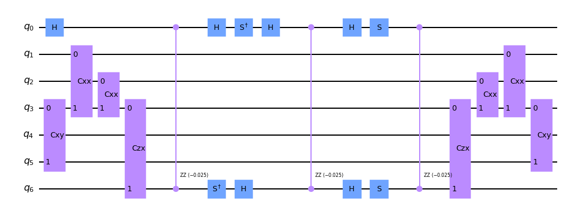

```python
blk_a.to_qiskit().draw('mpl', style='clifford', scale=0.7)
```

```
left_end_empty_layers: [4 1 2 0 5 0 3]
right_end_empty_layers: [4 1 2 0 5 0 3]
```

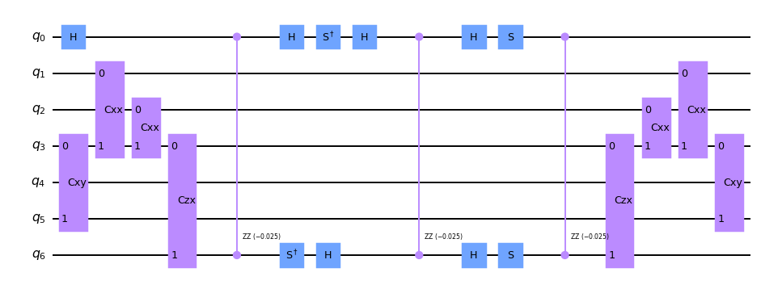

```python
print('left_end_empty_layers:', ordering.left_end_empty_layers(blk_a))
print('right_end_empty_layers:', ordering.right_end_empty_layers(blk_a))
blk_a.to_qiskit().draw(output='mpl', style='clifford', scale=0.7)
```

```
left_end_empty_layers: [3 0 0 0 0 1 2]
right_end_empty_layers: [3 0 2 0 2 1 2]
```

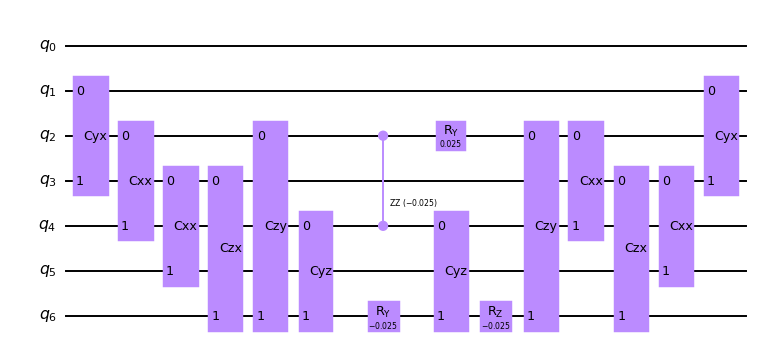

```python
print('left_end_empty_layers:', ordering.left_end_empty_layers(blk_b))
print('right_end_empty_layers:', ordering.right_end_empty_layers(blk_b))
blk_b.to_qiskit().draw(output='mpl', style='clifford', scale=0.7)
```

*Remark:*

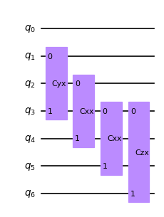

```python
# for example, the front_full_width_circuit of blk_b
passes.front_full_width_circuit(blk_b).to_qiskit().draw(output='mpl', style='clifford', scale=0.6)
```

```python
# The number of entangling layers of front_full_width_circuit(blk_b) is 3, so the first slot of left_end_empty_layers(blk_b) is 3
passes.front_full_width_circuit(blk_b).depth_nonlocal
```

```
3
```

Let us see the left and right empty num-layers of the two Circuit-Tetris instances.

```python
def plot_tetris_edge(left_end, right_end):
    import matplotlib.pyplot as plt

    offset = 0.1
    xlim = max(left_end) + max(right_end) + 2
    ylim = len(left_end)

    # left_edge_data = [(0, 0)]
    left_edge_data = []
    for i, end in enumerate(left_end):
        left_edge_data.append((end, i))
        left_edge_data.append((end, i + 1))
    # left_edge_data.append((0, ylim))
    left_x, left_y = [], []
    for data in left_edge_data:
        left_x.append(data[0])
        left_y.append(data[1])

    # right_edge_data = [(xlim, 0)]
    right_edge_data = []
    for i, end in enumerate(right_end):
        right_edge_data.append((xlim - end, i))
        right_edge_data.append((xlim - end, i + 1))
    # right_edge_data.append((xlim, ylim))
    right_x, right_y = [], []
    for data in right_edge_data:
        right_x.append(data[0])
        right_y.append(data[1])

    plt.figure(figsize=(3 * (xlim / ylim), 3))
    plt.plot(left_x, left_y, color='coral')
    plt.plot(right_x, right_y, color='coral')
    plt.xlim(-offset, xlim + offset)
    plt.ylim(0, ylim)
    # annotation left_edge_data
    for i, end in enumerate(left_end):
        plt.text(end + 0.3, i + 0.5, f'{end}', ha='center', va='center', fontsize=10, color='C0', fontdict={'weight': 'bold'})
    # annotation at right_edge_data
    for i, end in enumerate(right_end):
        plt.text(xlim - end - 0.3, i + 0.5, f'{end}', ha='center', va='center', fontsize=10, color='C0', fontdict={'weight': 'bold'})
    plt.xticks(range(xlim + 1))
    plt.yticks(range(ylim + 1))
    plt.gca().invert_yaxis()
    plt.grid(True, linestyle='--', alpha=0.7)

    plt.tight_layout()
    plt.show()
```

```python
left_empty_a, right_empty_a = ordering.left_end_empty_layers(blk_a), ordering.right_end_empty_layers(blk_a)
left_empty_b, right_empty_b = ordering.left_end_empty_layers(blk_b), ordering.right_end_empty_layers(blk_b)
```

```
[4 1 2 0 5 0 3] [4 1 2 0 5 0 3]
```

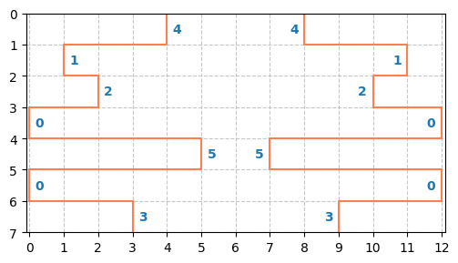

```python
print(left_empty_a, right_empty_a)
plot_tetris_edge(left_empty_a, right_empty_a)
```

```
[3 0 0 0 0 1 2] [3 0 2 0 2 1 2]
```

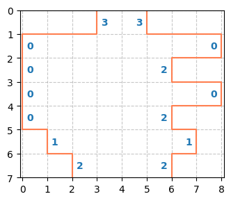

```python
print(left_empty_b, right_empty_b)
plot_tetris_edge(left_empty_b, right_empty_b)
```

Now we calculate the depth(2q)-overhead when assemble blk_a (in front) and blk_b (behind).

Result will be `(array([4, 1, 2, 0, 5, 0, 3]) + array([3, 0, 0, 0, 0, 1, 2])).sum() == 21`.

```python
def depth_overhead(lhs: np.ndarray, rhs: np.ndarray):
    """Calculate the basic circuit depth(2q) overhead once lhs and rhs are concatenated"""
    xor = np.logical_xor(lhs, rhs)
    if np.all(xor[(lhs == 0) | (rhs == 0)]):
        cost = (lhs + rhs - 1).sum()
    else:
        cost = (lhs + rhs).sum()
    return cost

# This function is also available in the `ordering` module
depth_overhead(right_empty_a, left_empty_b)
```

```
21
```

### Comparison with `Rustiq`

- In fact, `Rustiq` is not an end-to-end compiler like `Phoenix`. We can only calculate the synthesis effect (entangling count and depth statistics) in the logical circuit level. We cannot get perform any hardware mapping given the results acquired by `Rustiq`.
- Like what the original Rustiq's paper did, set `preserver_order=True` lead to better results overall.
- Like what the original Rustiq's paper did, we perform evaluation for `Rustiq-rcount` and `Rustiq-rdepth`, respectively.

Herein optimization rate is defined as $\frac{\#2Q_{\mathrm{after}}}{\#2Q_{\mathrm{before}}}$. The less, the better.

- Num2Q optimization results:
  - optimization rate (Rustiq-rcount) `0.3294`
  - optimization rate (Rustiq-rdepth) `0.3956`
  - optimization rate (Phoenix) `0.2115`
- Depth2Q optimization results:
  - optimization rate (Rustiq-rcount) `0.2423`
  - optimization rate (Rustiq-rdepth) `0.1799`
  - optimization rate (Phoenix) `0.1928`

```python
from rustiq import pauli_network_synthesis, Metric
from rustiq.utils import entangling_count, entangling_depth, convert_circuit

def rustiq_pass_rcount(paulis):
    circ = pauli_network_synthesis(paulis, Metric.COUNT) # preserve_order is True by default
    # because the returned circuit is a Clifford circuit on one side, we need to double the entangling count and depth
    return entangling_count(circ) * 2, entangling_depth(circ) * 2

def rustiq_pass_rdepth(paulis):
    circ = pauli_network_synthesis(paulis, Metric.DEPTH)
    return entangling_count(circ) * 2, entangling_depth(circ) * 2
```

```python
benchmark_dpath = '../benchmarks/uccsd_json'
fnames = [os.path.join(benchmark_dpath, fname) for fname in natsorted(os.listdir(benchmark_dpath))]
num_programs = len(fnames)
programs = [os.path.basename(fname).split('.')[0] for fname in fnames]
```

```python
result_rustiq = pd.DataFrame(columns=['program', 'num_2q_gates(rcount)', 'depth_2q(rcount)', 'num_2q_gates(rdepth)', 'depth_2q(rdepth)'])
for fname in tqdm(fnames):
    program_name = os.path.basename(fname).split('.')[0]
    with open(fname, 'r') as f:
        data = json.load(f)

    num_2q_rcount, depth_2q_rcount = rustiq_pass_rcount(data['paulis'])
    num_2q_rdepth, depth_2q_rdepth = rustiq_pass_rdepth(data['paulis'])
    result_rustiq = pd.concat([result_rustiq, pd.DataFrame({
        'program': program_name,
        'num_2q_gates(rcount)': num_2q_rcount,
        'depth_2q(rcount)': depth_2q_rcount,
        'num_2q_gates(rdepth)': num_2q_rdepth,
        'depth_2q(rdepth)': depth_2q_rdepth
    }, index=[0])], ignore_index=True)
```

```python
result_rustiq
```

|  | program | num_2q_gates(rcount) | depth_2q(rcount) | num_2q_gates(rdepth) | depth_2q(rdepth) |
| --- | --- | --- | --- | --- | --- |
| 0 | CH2_cmplt_BK_sto3g | 7056 | 4854 | 8534 | 3434 |
| 1 | CH2_cmplt_JW_sto3g | 6444 | 4344 | 8640 | 3460 |
| 2 | CH2_frz_BK_sto3g | 3442 | 2506 | 4398 | 1814 |
| 3 | CH2_frz_JW_sto3g | 3396 | 2346 | 3894 | 1752 |
| 4 | H2O_cmplt_BK_sto3g | 4474 | 3056 | 5326 | 2208 |
| 5 | H2O_cmplt_JW_sto3g | 4562 | 3152 | 5250 | 2236 |
| 6 | H2O_frz_BK_sto3g | 2702 | 1906 | 3050 | 1370 |
| 7 | H2O_frz_JW_sto3g | 2750 | 2026 | 3050 | 1342 |
| 8 | LiH_cmplt_BK_sto3g | 2624 | 1846 | 3242 | 1376 |
| 9 | LiH_cmplt_JW_sto3g | 2660 | 1884 | 3300 | 1396 |
| 10 | LiH_frz_BK_sto3g | 464 | 362 | 644 | 304 |
| 11 | LiH_frz_JW_sto3g | 492 | 356 | 654 | 324 |
| 12 | NH_cmplt_BK_sto3g | 2702 | 1906 | 3050 | 1370 |
| 13 | NH_cmplt_JW_sto3g | 2750 | 2026 | 3050 | 1342 |
| 14 | NH_frz_BK_sto3g | 1370 | 1034 | 1590 | 736 |
| 15 | NH_frz_JW_sto3g | 1332 | 950 | 1494 | 762 |

```python
result_phoenix = pd.read_csv('./results/result_uccsd_phoenix.csv')[['program', 'num_qubits', 'num_2q_gates', 'depth_2q', 'num_2q_gates(all2all)', 'depth_2q(all2all)']]
```

```python
result_phoenix
```

|  | program | num_qubits | num_2q_gates | depth_2q | num_2q_gates(all2all) | depth_2q(all2all) |
| --- | --- | --- | --- | --- | --- | --- |
| 0 | CH2_cmplt_BK | 14 | 19574 | 19399 | 4112 | 3483 |
| 1 | CH2_cmplt_JW | 14 | 21072 | 19749 | 4150 | 3636 |
| 2 | CH2_frz_BK | 12 | 10228 | 10174 | 2214 | 1909 |
| 3 | CH2_frz_JW | 12 | 10344 | 9706 | 2202 | 1973 |
| 4 | H2O_cmplt_BK | 14 | 13108 | 12976 | 2810 | 2406 |
| 5 | H2O_cmplt_JW | 14 | 14360 | 13576 | 2808 | 2514 |
| 6 | H2O_frz_BK | 12 | 8004 | 7934 | 1418 | 1195 |
| 7 | H2O_frz_JW | 12 | 8064 | 7613 | 1740 | 1564 |
| 8 | LiH_cmplt_BK | 12 | 8680 | 8637 | 1484 | 1285 |
| 9 | LiH_cmplt_JW | 12 | 8064 | 7616 | 1702 | 1535 |
| 10 | LiH_frz_BK | 10 | 1442 | 1438 | 402 | 367 |
| 11 | LiH_frz_JW | 10 | 1616 | 1576 | 380 | 367 |
| 12 | NH_cmplt_BK | 12 | 8004 | 7934 | 1418 | 1195 |
| 13 | NH_cmplt_JW | 12 | 8064 | 7613 | 1740 | 1564 |
| 14 | NH_frz_BK | 10 | 4178 | 4160 | 1012 | 889 |
| 15 | NH_frz_JW | 10 | 3896 | 3674 | 930 | 846 |

```
#2Q optimization results:
optimization rate (Rustiq-rcount) 0.3294
optimization rate (Rustiq-rdepth) 0.3956
optimization rate (Phoenix) 0.2115
```

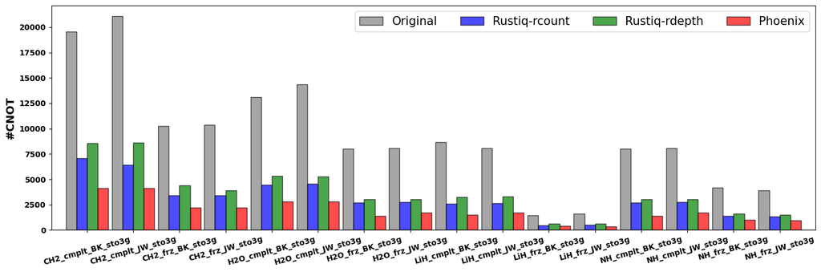

```python
# num_2q_gates

print('#2Q optimization results:')
print('optimization rate (Rustiq-rcount)', gmean((result_rustiq['num_2q_gates(rcount)'] / result_phoenix['num_2q_gates']).to_numpy().astype(float)).round(4))
print('optimization rate (Rustiq-rdepth)', gmean((result_rustiq['num_2q_gates(rdepth)'] / result_phoenix['num_2q_gates']).to_numpy().astype(float)).round(4))
print('optimization rate (Phoenix)', gmean((result_phoenix['num_2q_gates(all2all)'] / result_phoenix['num_2q_gates']).to_numpy().astype(float)).round(4))


plt.figure(figsize=(15, 5))
width = 0.23
plt.bar(np.arange(num_programs) - width * 1.5, result_phoenix['num_2q_gates'], width=width, label='Original', edgecolor='black', color='gray', alpha=0.7)
plt.bar(np.arange(num_programs) - width * 0.5, result_rustiq['num_2q_gates(rcount)'], width=width, label='Rustiq-rcount', edgecolor='black', color='blue', alpha=0.7)
plt.bar(np.arange(num_programs) + width * 0.5, result_rustiq['num_2q_gates(rdepth)'], width=width, label='Rustiq-rdepth', edgecolor='black', color='green', alpha=0.7)
plt.bar(np.arange(num_programs) + width * 1.5, result_phoenix['num_2q_gates(all2all)'], width=width, label='Phoenix', edgecolor='black', color='red', alpha=0.7)

plt.xticks(np.arange(num_programs), programs, rotation=15, fontweight='bold')
plt.xlim(width - 1, num_programs - width)
plt.ylabel('#CNOT', fontsize=14, fontweight='bold')
plt.yticks(fontweight='bold')
plt.legend(fontsize=15, loc='upper right', ncol=4)

plt.tight_layout()
plt.show()
```

```
Depth2Q optimization results:
optimization rate (Rustiq-rcount) 0.2423
optimization rate (Rustiq-rdepth) 0.1799
optimization rate (Phoenix) 0.1928
```

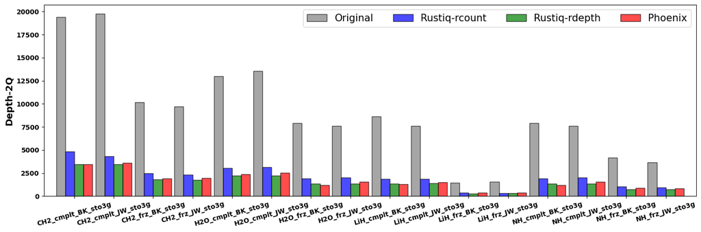

```python
# depth_2q

print('Depth2Q optimization results:')
print('optimization rate (Rustiq-rcount)', gmean((result_rustiq['depth_2q(rcount)'] / result_phoenix['depth_2q']).to_numpy().astype(float)).round(4))
print('optimization rate (Rustiq-rdepth)', gmean((result_rustiq['depth_2q(rdepth)'] / result_phoenix['depth_2q']).to_numpy().astype(float)).round(4))
print('optimization rate (Phoenix)', gmean((result_phoenix['depth_2q(all2all)'] / result_phoenix['depth_2q']).to_numpy().astype(float)).round(4))

plt.figure(figsize=(15, 5))
width = 0.23
plt.bar(np.arange(num_programs) - width * 1.5, result_phoenix['depth_2q'], width=width, label='Original', edgecolor='black', color='gray', alpha=0.7)
plt.bar(np.arange(num_programs) - width * 0.5, result_rustiq['depth_2q(rcount)'], width=width, label='Rustiq-rcount', edgecolor='black', color='blue', alpha=0.7)
plt.bar(np.arange(num_programs) + width * 0.5, result_rustiq['depth_2q(rdepth)'], width=width, label='Rustiq-rdepth', edgecolor='black', color='green', alpha=0.7)
plt.bar(np.arange(num_programs) + width * 1.5, result_phoenix['depth_2q(all2all)'], width=width, label='Phoenix', edgecolor='black', color='red', alpha=0.7)

plt.xticks(np.arange(num_programs), programs, rotation=15, fontweight='bold')
plt.xlim(width - 1, num_programs - width)
plt.ylabel('Depth-2Q', fontsize=14, fontweight='bold')
plt.yticks(fontweight='bold')
plt.legend(fontsize=15, loc='upper right', ncol=4)

plt.tight_layout()
plt.show()
```

### Ablation study of `Phoenix`

```python
benchmark_dpath = '../benchmarks/uccsd_json'
fnames = [os.path.join(benchmark_dpath, fname) for fname in natsorted(os.listdir(benchmark_dpath))]
num_programs = len(fnames)
programs = [os.path.basename(fname).split('.')[0] for fname in fnames]

result = pd.read_csv('./results/result_uccsd_phoenix.csv')[['program', 'num_qubits', 'num_2q_gates', 'depth_2q', 'num_2q_gates(all2all)', 'depth_2q(all2all)', 'num_2q_gates(all2all_opt)', 'depth_2q(all2all_opt)']]
result = result.rename({'num_2q_gates(all2all)': 'num_2q_gates(phoenix)', 'depth_2q(all2all)': 'depth_2q(phoenix)', 'num_2q_gates(all2all_opt)': 'num_2q_gates(phoenix_opt)', 'depth_2q(all2all_opt)': 'depth_2q(phoenix_opt)'}, axis=1)
```

```python
result_ablation = pd.DataFrame(columns=['program', 'num_2q_gates(phoenix_bsf)', 'depth_2q(phoenix_bsf)', 'num_2q_gates(phoenix_bsf_order)', 'depth_2q(phoenix_bsf_order)'])
for fname in tqdm(fnames):
    program_name = os.path.basename(fname).split('.')[0]
    with open(fname, 'r') as f:
        data = json.load(f)
    ham = HamiltonianModel(data['paulis'], data['coeffs'])
    circ_bsf = ham.phoenix_circuit(order=False)
    circ_bsf_order = ham.phoenix_circuit(efficient=True)

    result_ablation = pd.concat([result_ablation, pd.DataFrame({
        'program': program_name,
        'num_2q_gates(phoenix_bsf)': circ_bsf.num_nonlocal_gates,
        'depth_2q(phoenix_bsf)': circ_bsf.depth_nonlocal,
        'num_2q_gates(phoenix_bsf_order)': circ_bsf_order.num_nonlocal_gates,
        'depth_2q(phoenix_bsf_order)': circ_bsf_order.depth_nonlocal
    }, index=[0])], ignore_index=True)

# result_ablation.to_csv('./results/result_uccsd_phoenix_ablation.csv', index=False)
```

```
#2Q optimization results:
optimization rate (Phoenix-BSF) 0.2359
optimization rate (Phoenix-BSF-Order) 0.2314
optimization rate (Phoenix) 0.2115
optimization rate (Phoenix + O3) 0.1956
```

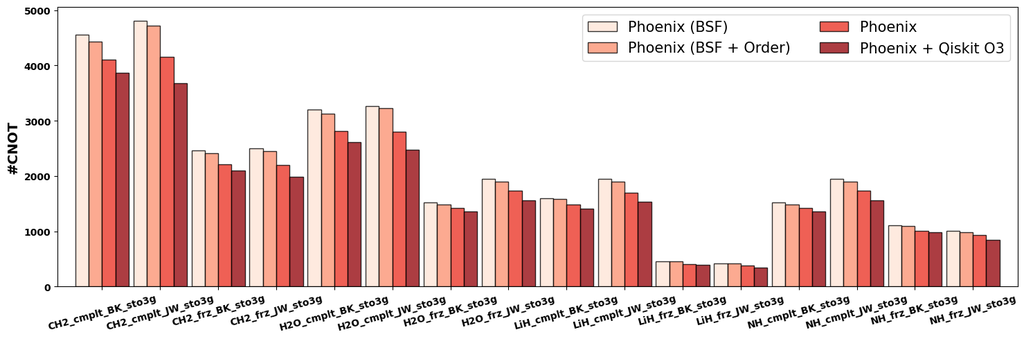

```python
# num_2q_gates

print('#2Q optimization results:')
print('optimization rate (Phoenix-BSF)', gmean((result_ablation['num_2q_gates(phoenix_bsf)'] / result['num_2q_gates']).to_numpy().astype(float)).round(4))
print('optimization rate (Phoenix-BSF-Order)', gmean((result_ablation['num_2q_gates(phoenix_bsf_order)'] / result['num_2q_gates']).to_numpy().astype(float)).round(4))
print('optimization rate (Phoenix)', gmean((result['num_2q_gates(phoenix)'] / result['num_2q_gates']).to_numpy().astype(float)).round(4))
print('optimization rate (Phoenix + O3)', gmean((result['num_2q_gates(phoenix_opt)'] / result['num_2q_gates']).to_numpy().astype(float)).round(4))

colors = plt.cm.Reds(np.linspace(0.1, 0.9, 4)).tolist()


plt.figure(figsize=(15, 5))
width = 0.23

plt.bar(np.arange(num_programs) - width * 1.5, result_ablation['num_2q_gates(phoenix_bsf)'], width=width, label='Phoenix (BSF)', edgecolor='black', color=colors[0], alpha=0.8)
plt.bar(np.arange(num_programs) - width * 0.5, result_ablation['num_2q_gates(phoenix_bsf_order)'], width=width, label='Phoenix (BSF + Order)', edgecolor='black', color=colors[1], alpha=0.8)
plt.bar(np.arange(num_programs) + width * 0.5, result['num_2q_gates(phoenix)'], width=width, label='Phoenix', edgecolor='black', color=colors[2], alpha=0.8)
plt.bar(np.arange(num_programs) + width * 1.5, result['num_2q_gates(phoenix_opt)'], width=width, label='Phoenix + Qiskit O3', edgecolor='black', color=colors[3], alpha=0.8)

plt.xticks(np.arange(num_programs), programs, rotation=15, fontweight='bold')
plt.xlim(width - 1, num_programs - width)
plt.ylabel('#CNOT', fontsize=14, fontweight='bold')
plt.yticks(fontweight='bold')
plt.legend(fontsize=15, loc='upper right', ncol=2)

plt.tight_layout()
plt.show()
```

```python
def lower_rate(r1, r0):
    return (r1 - r0) / r1
```

```python
#2Q optimization results:
# optimization rate (Phoenix-BSF) 0.2359
# optimization rate (Phoenix-BSF-Order) 0.2314
# optimization rate (Phoenix) 0.2115
# optimization rate (Phoenix + O3) 0.1956

print('improvement rate: Phoenix (BSFSimp + Order) v.s. Phoenix (BSF): {:.2f}%'.format(100*(gmean((1 - result_ablation['num_2q_gates(phoenix_bsf_order)'] / result_ablation['num_2q_gates(phoenix_bsf)']).astype(float)))))
print('improvement rate: Phoenix v.s. Phoenix (BSFSimp + Order): {:.2f}%'.format(100*(gmean((1 - result['num_2q_gates(phoenix)'] / result_ablation['num_2q_gates(phoenix_bsf_order)']).astype(float)))))
print('improvement rate: Phoenix v.s. No Qiskit O3: {:.2f}%'.format(100*(gmean((1 - result['num_2q_gates(phoenix_opt)'] / result['num_2q_gates(phoenix)']).astype(float)))))
```

```
improvement rate: Phoenix (BSFSimp + Order) v.s. Phoenix (BSF): 1.89%
improvement rate: Phoenix v.s. Phoenix (BSFSimp + Order): 8.25%
improvement rate: Phoenix v.s. No Qiskit O3: 6.58%
```

```
Depth2Q optimization results:
optimization rate (Phoenix-BSF) 0.2151
optimization rate (Phoenix-BSF-Order) 0.2076
optimization rate (Phoenix) 0.1928
optimization rate (Phoenix + O3) 0.1729
```

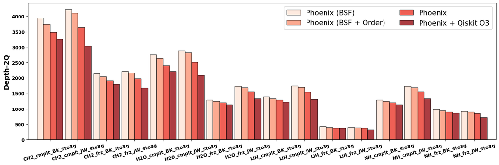

```python
# depth_2q

print('Depth2Q optimization results:')
print('optimization rate (Phoenix-BSF)', gmean((result_ablation['depth_2q(phoenix_bsf)'] / result['depth_2q']).to_numpy().astype(float)).round(4))
print('optimization rate (Phoenix-BSF-Order)', gmean((result_ablation['depth_2q(phoenix_bsf_order)'] / result['depth_2q']).to_numpy().astype(float)).round(4))
print('optimization rate (Phoenix)', gmean((result['depth_2q(phoenix)'] / result['depth_2q']).to_numpy().astype(float)).round(4))
print('optimization rate (Phoenix + O3)', gmean((result['depth_2q(phoenix_opt)'] / result['depth_2q']).to_numpy().astype(float)).round(4))

plt.figure(figsize=(15, 5))
width = 0.23

plt.bar(np.arange(num_programs) - width * 1.5, result_ablation['depth_2q(phoenix_bsf)'], width=width, label='Phoenix (BSF)', edgecolor='black', color=colors[0], alpha=0.8)
plt.bar(np.arange(num_programs) - width * 0.5, result_ablation['depth_2q(phoenix_bsf_order)'], width=width, label='Phoenix (BSF + Order)', edgecolor='black', color=colors[1], alpha=0.8)
plt.bar(np.arange(num_programs) + width * 0.5, result['depth_2q(phoenix)'], width=width, label='Phoenix', edgecolor='black', color=colors[2], alpha=0.8)
plt.bar(np.arange(num_programs) + width * 1.5, result['depth_2q(phoenix_opt)'], width=width, label='Phoenix + Qiskit O3', edgecolor='black', color=colors[3], alpha=0.8)

plt.xticks(np.arange(num_programs), programs, rotation=15, fontweight='bold')
plt.xlim(width - 1, num_programs - width)
plt.ylabel('Depth-2Q', fontsize=14, fontweight='bold')
plt.yticks(fontweight='bold')
plt.legend(fontsize=15, loc='upper right', ncol=2)

plt.tight_layout()
plt.show()
```

```python
# Depth2Q optimization results:
# optimization rate (Phoenix-BSF) 0.2151
# optimization rate (Phoenix-BSF-Order) 0.2076
# optimization rate (Phoenix) 0.1928
# optimization rate (Phoenix + O3) 0.1729

print('improvement rate: Phoenix (BSFSimp + Order) v.s. Phoenix (BSF): {:.2f}%'.format(100*(gmean((1 - result_ablation['depth_2q(phoenix_bsf_order)'] / result_ablation['depth_2q(phoenix_bsf)']).astype(float)))))
print('improvement rate: Phoenix v.s. Phoenix (BSFSimp + Order): {:.2f}%'.format(100*(gmean((1 - result['depth_2q(phoenix)'] / result_ablation['depth_2q(phoenix_bsf_order)']).astype(float)))))
print('improvement rate: Phoenix v.s. No Qiskit O3: {:.2f}%'.format(100*(gmean((1 - result['depth_2q(phoenix_opt)'] / result['depth_2q(phoenix)']).astype(float)))))
```

```
improvement rate: Phoenix (BSFSimp + Order) v.s. Phoenix (BSF): 3.23%
improvement rate: Phoenix v.s. Phoenix (BSFSimp + Order): 6.66%
improvement rate: Phoenix v.s. No Qiskit O3: 8.42%
```